# Part II - (Ford Gobike Data Presentation)

## by (Rawan Alsaedi)

## Investigation Overview

In this investigation, I wanted to look at the different factors affecting the number of bike trips and the duration of trips, such as: Gender - age - user type - days of week.

## Dataset Overview

The dataset includes information about individual rides made in a bike-sharing system covering the greater San Francisco Bay area and containing the trip data of the ford gobike about 183,412 with 16 features.

### Percentage Bike Rides Users per Gender

Male took around 74% of all bike rides, female took around %24 and other took around %2 of them.

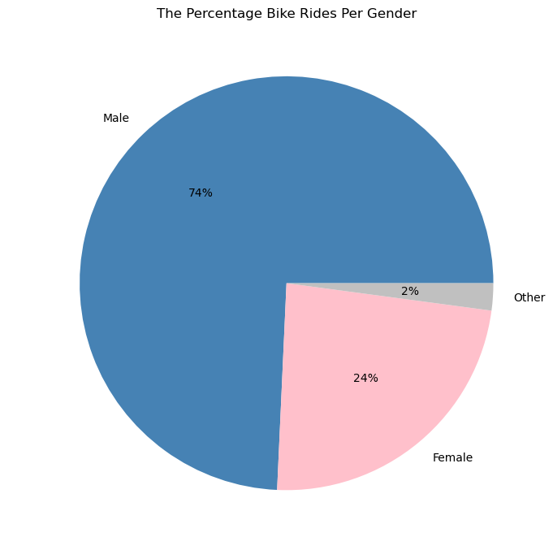

### Distribution of Trip Durations per Users Type , Gender and Weekday

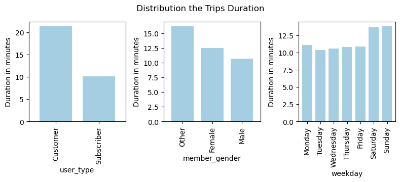

### Distribution of Bike Users Age over Weekday

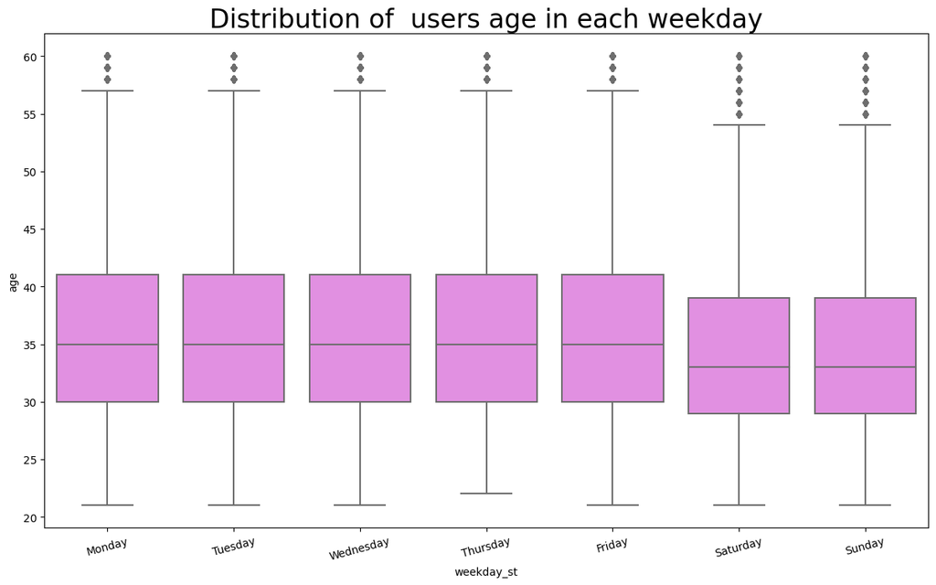

### Distribution of the relationship between users age & type and trips duration

The customer users have longer trip duration than subscriber users. Surprisingly, the younger customers had longer trip duration than older customers .

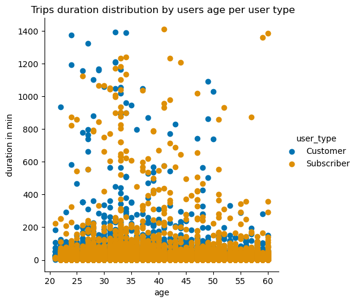